# Life Expectancy at Birth App

12/20/2018

## Life Expectancy at Birth

- Life expectancy at birth is defined as "… a statistical measure of the average time an organism is expected to live, based on the year of its birth, its current age and other demographic factors including gender." (Source: Wikipedia)
- Worldwide, life expectancy at birth shows an incremental trend for most countries.
- The trends vary by country and by sex.

## The App

- The "Life Expectancy at Birth App" allows the user to explore this variable interactively.
- Posible analyses include:
- Life expectancy at birth for a given country, sex and year of birth.
- Life expectancy trend in a given country.
- Life expectancy in a given country compared to World statistics.
- It is powered by data provided by the Institute for Health Metrics and Evaluation, University of Washington (https://www.gapminder.org/data/documentation/gd004/)

## Demo: Life expectancy at birth in Guatemala for a person born in 1978

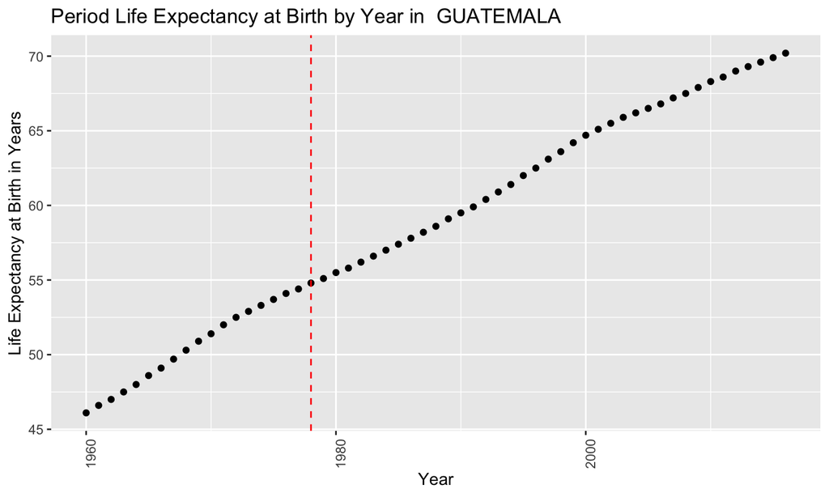

```r
life_expectancies_by_country_qplot
```

## Conclusion and Invitation

- Understanding World through data can be an enlightening endeavour.
- This app represents a tool to understand a fundamental variable to understand human progress, you are invited to use it !